# Usuarios de Smartphones

## Análisis Exploratorio de Datos (AED)

### Descripción del dataset

```r
glimpse(users)
```

```
## Rows: 1,000
## Columns: 10
## $ user_id                      <int> 1, 2, 3, 4, 5, 6, 7, 8, 9, 10, 11, 12, 13…
## $ age                          <int> 56, 46, 32, 25, 38, 56, 36, 40, 28, 28, 4…
## $ gender                       <chr> "Male", "Male", "Female", "Female", "Male…
## $ total_app_usage_hours        <dbl> 2.61, 2.13, 7.28, 1.20, 6.31, 3.31, 4.81,…
## $ daily_screen_time_hours      <dbl> 7.15, 13.79, 4.50, 6.29, 12.59, 1.04, 1.5…
## $ number_apps_used             <int> 24, 18, 11, 21, 14, 21, 24, 11, 9, 16, 21…
## $ social_media_usage_hours     <dbl> 4.43, 4.67, 4.58, 3.18, 3.15, 2.02, 3.76,…
## $ productivity_app_usage_hours <dbl> 0.55, 4.42, 1.71, 3.42, 0.13, 3.45, 1.58,…
## $ gaming_app_usage_hours       <dbl> 2.40, 2.43, 2.83, 4.58, 4.00, 2.26, 3.59,…
## $ location                     <chr> "Los Angeles", "Chicago", "Houston", "Pho…
```

Como podemos obervar, tenemos en total 1000 y 10 variables. Por conveniencia, vamos a modificar los nombres de las variables para tener su nombre en minúsculas.

```r
temp <- names(users)
names(users) <- tolower(temp)
rm(temp)
```

Es conveniente tener una variable para representar cada uno de los tres grupos de edad: Adulto, media edad, adulto mayor.

```r
users <- mutate(users, age_group = case_when(age >= 18 & age < 40 ~ "A",
                                             age >= 40 & age < 60 ~ "EM",
                                             age >= 60 ~ "AM"  ), .after = age)
```

# Análisis Descriptivo

Esta sección presenta un resumen estádistico del conjunto de datos.

### Edad de los usuario

La edad de los usuarios tiene una media = 38.745 y una desviación estándard = 12.1867342. La edad media para las mujeres es 39.4037267 ( sd = 12.1313928). La edad media para usuarios de género masculino es 38.1295938 ( sd = 12.217848).

```
##    Min. 1st Qu.  Median    Mean 3rd Qu.    Max.
##   18.00   28.00   40.00   38.74   50.00   59.00
```

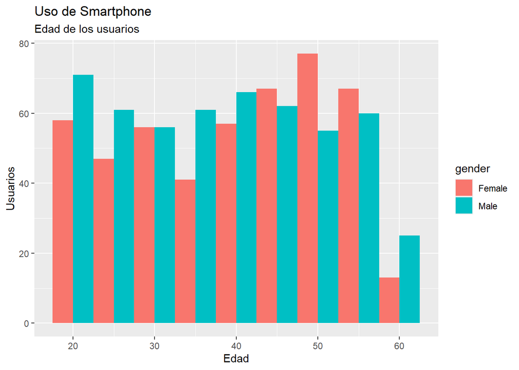

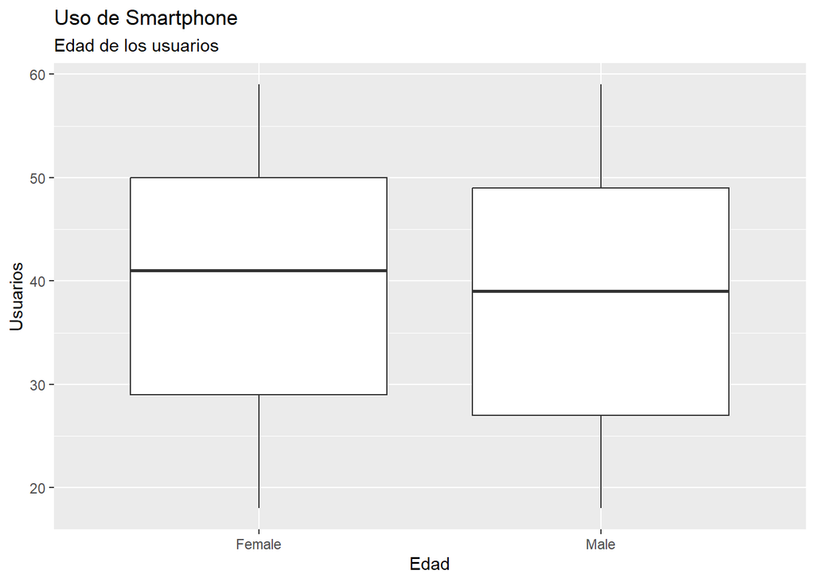

### Género de los usuarios

En la siguiente tabla se muestra un resumen de los usuarios por género.

Género de los usuarios.

| gender | n | pct |
| --- | --- | --- |
| Male | 517 | 51.7 |
| Female | 483 | 48.3 |

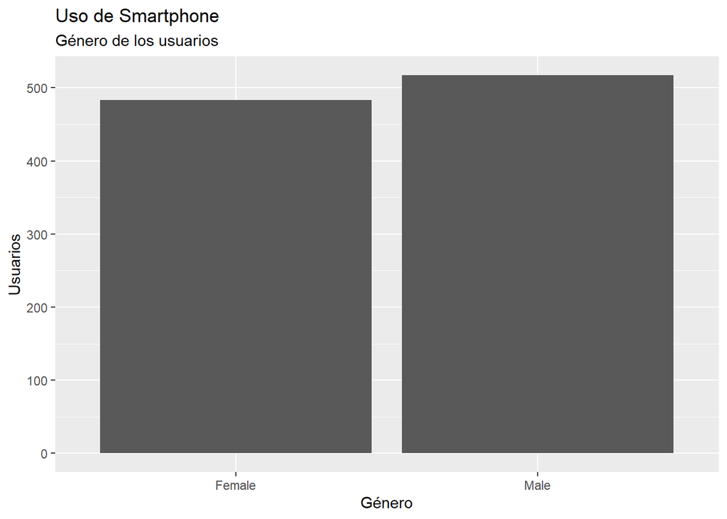

### Ubicación de los usuarios

En la siguiente tabla se muestra un resumen de los usuarios por su ubicación.

Ubicación de los usuarios.

| location | n | pct |
| --- | --- | --- |
| Los Angeles | 185 | 18.5 |
| Chicago | 192 | 19.2 |
| Houston | 181 | 18.1 |
| Phoenix | 199 | 19.9 |
| New York | 243 | 24.3 |

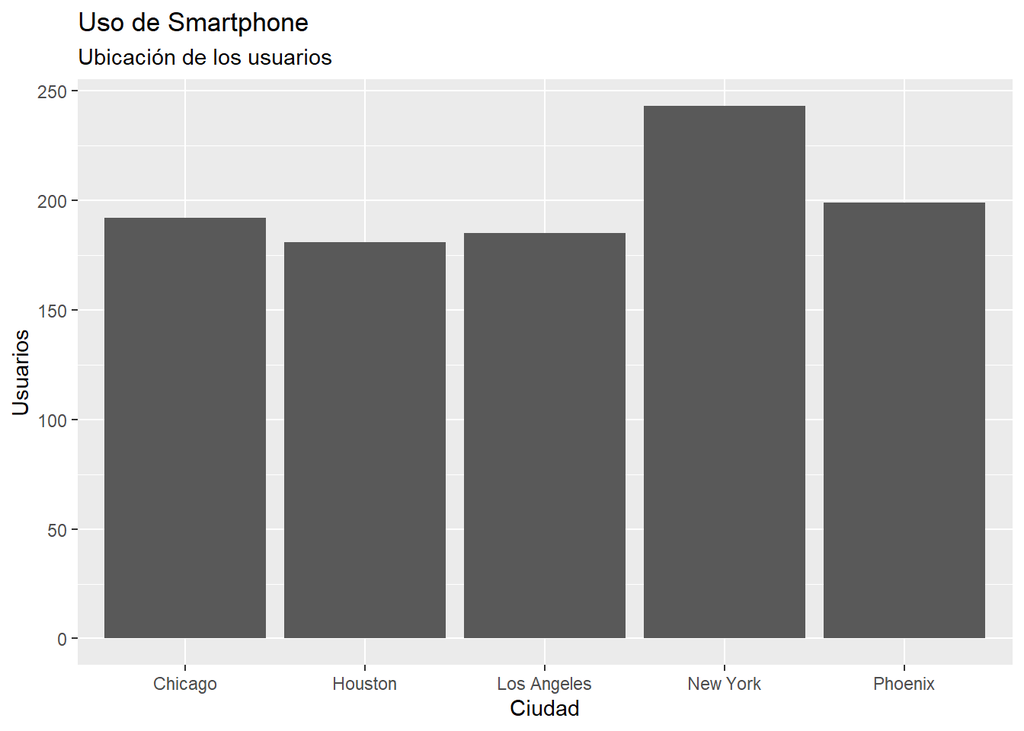

### Uso de aplicaciones

El tiempo total de uso de aplicaciones para cada usuario esta dado por la variable *total_app_usage_hours*. Esta variable tiene una media = 6.40567 (sd=3.1348553).

```
##    Min. 1st Qu.  Median    Mean 3rd Qu.    Max.
##   1.000   3.590   6.455   6.406   9.123  11.970
```

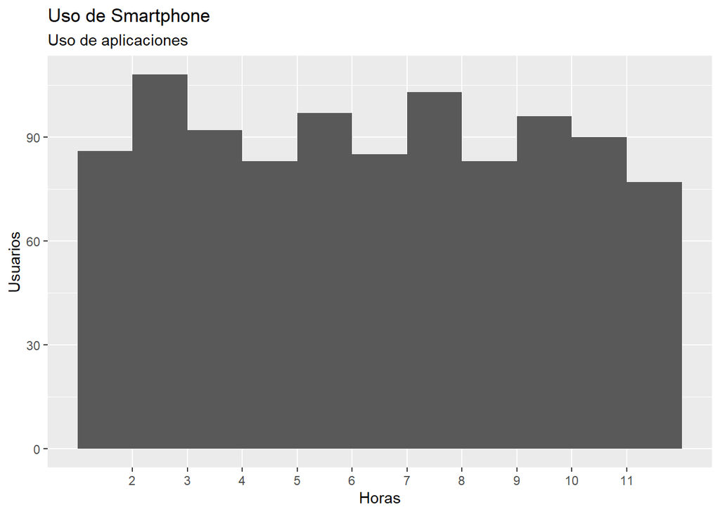

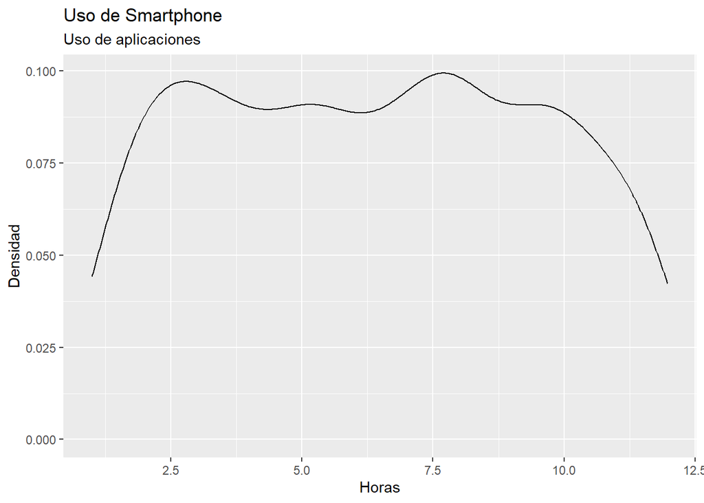

La siguiente gráfica compara el tiempo de uso en función de la edad.

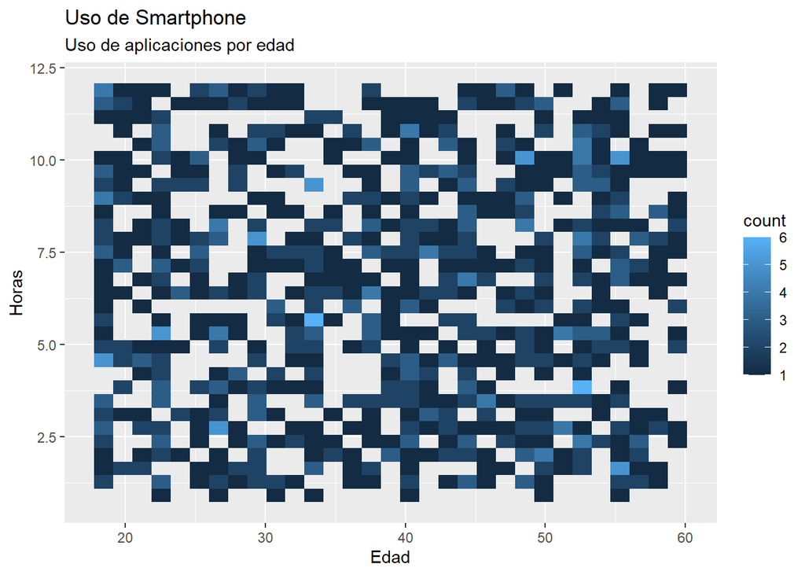